# Mncedisi_Mncwabe_Assessment

```python
import pandas as pd
import numpy as np
import seaborn as sns
import datetime as dt
import matplotlib.pyplot as plt
from IPython.display import display
from sklearn.preprocessing import StandardScaler
import json
from datetime import datetime
from sklearn import metrics
from sklearn.metrics import accuracy_score,roc_auc_score,roc_curve,precision_recall_curve,f1_score
from sklearn.metrics import confusion_matrix, precision_score,classification_report, ConfusionMatrixDisplay
from sklearn.model_selection import train_test_split, GridSearchCV, cross_val_score, StratifiedKFold, StratifiedShuffleSplit
from sklearn.model_selection import RandomizedSearchCV
from sklearn.ensemble import RandomForestClassifier
from xgboost import XGBClassifier
from sklearn.cluster import KMeans
import shap
import warnings
warnings.filterwarnings('ignore')
warnings.filterwarnings("ignore")
pd.set_option('display.max_columns', None)
pd.set_option('display.max_rows', None)
```

### 1. Feature Engineering

```python
def extract_credit_features(credit_reports):
    """
    Extracts relevant features from credit reports for credit scoring.

    Args:
        credit_reports (list): A list of credit report dictionaries.
                               Each dictionary should have 'application_id' and 'data' keys.

    Returns:
        pandas.DataFrame: A DataFrame containing the application_id and the extracted features.
    """

    extracted_features = []
    for report in credit_reports:
        application_id = report['application_id']
        data = report['data']
        features = {'application_id': application_id}

        try:
            consumerfullcredit = data.get('consumerfullcredit', {})

            # 1. Account Summary Features
            creditaccountsummary = consumerfullcredit.get('creditaccountsummary', {})
            features['total_accounts'] = int(creditaccountsummary.get('totalaccounts', 0))
            features['total_account_arrear'] = int(creditaccountsummary.get('totalaccountarrear', 0))
            features['total_outstanding_debt'] = float(creditaccountsummary.get('totaloutstandingdebt', 0).replace(',', '')) if creditaccountsummary.get('totaloutstandingdebt') is not None else 0
            features['total_monthly_instalment'] = float(creditaccountsummary.get('totalmonthlyinstalment', 0).replace(',', '')) if creditaccountsummary.get('totalmonthlyinstalment') is not None else 0
            features['account_summary_rating'] = int(creditaccountsummary.get('rating', 0))

            # 2. Enquiry History Features
            enquiryhistory = consumerfullcredit.get('enquiryhistorytop', [])
            features['num_recent_enquiries'] = len(enquiryhistory)
            if enquiryhistory:
                recent_enquiry_date_str = enquiryhistory[0].get('daterequested')
                if recent_enquiry_date_str:
                    try:
                        recent_enquiry_date = datetime.strptime(recent_enquiry_date_str.split(' ')[0], '%d/%m/%Y')
                        features['days_since_last_enquiry'] = (datetime.now() - recent_enquiry_date).days
                    except ValueError:
                        features['days_since_last_enquiry'] = None
                else:
                    features['days_since_last_enquiry'] = None
            else:
                features['days_since_last_enquiry'] = None

            # 3. Credit Agreement Summary Features
            creditagreements = consumerfullcredit.get('creditagreementsummary', [])
            num_open_accounts = 0
            num_closed_accounts = 0
            total_overdue = 0
            total_credit_limit = 0
            for agreement in creditagreements:
                if agreement.get('accountstatus') == 'Open':
                    num_open_accounts += 1
                    total_overdue += float(agreement.get('amountoverdue', 0).replace(',', '')) if agreement.get('amountoverdue') is not None else 0
                    opening_balance_str = agreement.get('openingbalanceamt')
                    if opening_balance_str:
                        try:
                            total_credit_limit += float(opening_balance_str.replace(',', ''))
                        except ValueError:
                            pass
                elif agreement.get('accountstatus') == 'Closed':
                    num_closed_accounts += 1

            features['num_open_accounts'] = num_open_accounts
            features['num_closed_accounts'] = num_closed_accounts
            features['total_overdue_amount'] = total_overdue
            features['total_credit_limit'] = total_credit_limit
            features['credit_utilization_ratio'] = (features['total_outstanding_debt'] / total_credit_limit) if total_credit_limit > 0 else None


            # 4. Personal Details Summary Features
            personaldetailssummary = consumerfullcredit.get('personaldetailssummary', {})
            features['gender'] = personaldetailssummary.get('gender')
            features['dependants'] = int(personaldetailssummary.get('dependants', 0))


            # 5. Account Rating Features
            accountrating = consumerfullcredit.get('accountrating', {})
            features['num_good_accounts'] = int(accountrating.get('noofotheraccountsgood', 0))
            features['num_bad_accounts'] = int(accountrating.get('noofotheraccountsbad', 0))
            features['ratio_good_to_bad_accounts'] = (features['num_good_accounts'] / features['num_bad_accounts']) if features['num_bad_accounts'] > 0 else features['num_good_accounts']


            # 6. Employment History Feature
            employment_history = consumerfullcredit.get('employmenthistory', [])
            features['years_of_employment'] = len(employment_history)

            # 7. Delinquency Information
            deliquency_info = consumerfullcredit.get('deliquencyinformation', {})
            features['months_in_arrears'] = int(deliquency_info.get('monthsinarrears', 0))

            extracted_features.append(features)

        except Exception as e:
            print(f"Error processing application {application_id}: {e}")
            extracted_features.append({'application_id': application_id, 'error': str(e)})

    return pd.DataFrame(extracted_features)

# Load the data
with open('credit_report_sample.json', 'r') as f:
    credit_reports = json.load(f)

# Extract features and convert to DataFrame
df_features = extract_credit_features(credit_reports)
df_features.head()
```

|  | application_id | total_accounts | total_account_arrear | total_outstanding_debt | total_monthly_instalment | account_summary_rating | num_recent_enquiries | days_since_last_enquiry | num_open_accounts | num_closed_accounts | total_overdue_amount | total_credit_limit | credit_utilization_ratio | gender | dependants | num_good_accounts | num_bad_accounts | ratio_good_to_bad_accounts | years_of_employment | months_in_arrears |
| --- | --- | --- | --- | --- | --- | --- | --- | --- | --- | --- | --- | --- | --- | --- | --- | --- | --- | --- | --- | --- |
| 0 | 9711360 | 7 | 2 | 105435.0 | 77404.0 | 13 | 15 | 1743 | 3 | 1 | 22441.39 | 885179.98 | 0.119111 | Male | 0 | 3 | 0 | 3 | 5 | 13 |
| 1 | 9714953 | 17 | 1 | 294770.0 | 132176.0 | 2 | 10 | 1749 | 4 | 10 | 0.00 | 148000.00 | 1.991689 | Female | 0 | 3 | 0 | 3 | 5 | 2 |
| 2 | 9714978 | 3 | 1 | 110919.0 | 7000.0 | 109 | 10 | 1749 | 3 | 0 | 12000.00 | 1090936.00 | 0.101673 | Female | 0 | 1 | 0 | 1 | 5 | 109 |

#### Explanation and justification of features of how they could be relevant to improve the risk scoring model.

`total_accounts`:

- Relevance: A high number of total accounts might indicate that the applicant is heavily reliant on credit or has a complex financial history. This can increase the risk of default if the applicant struggles to manage multiple payments.

`total_account_arrear`:

- Relevance: The number of accounts in arrears is a direct indicator of past repayment behavior. A higher number suggests a higher risk of future delinquency.

`total_outstanding_debt`:

- Relevance: The total amount of outstanding debt reflects the applicant's current financial obligations. A high debt burden relative to income increases the risk of default.

`total_monthly_instalment`:

- Relevance: This indicates the applicant's current monthly repayment obligations. A high amount can strain their finances and increase the risk of default.

`num_recent_enquiries`:

- Relevance: A large number of recent credit enquiries can suggest that the applicant is actively seeking credit, possibly due to financial difficulties. This can be a red flag for increased risk.

`days_since_last_enquiry`:

- Relevance: This feature complements num_recent_enquiries. A very recent enquiry might be more concerning than one further in the past. It helps to assess the recency of credit-seeking behavior.

`num_open_accounts`:

- Relevance: Open accounts represent active credit lines. A higher number means more ongoing financial commitments.

`num_closed_accounts`:

- Relevance: Closed accounts can indicate past credit experience. A mix of open and closed accounts can provide a more complete picture.

`total_overdue_amount`:

- Relevance: This is a critical indicator of current repayment problems. A higher overdue amount directly correlates with higher risk.

`gender`:

- Relevance: While ethically sensitive, gender can sometimes show patterns in credit behavior. However, it's crucial to use this feature responsibly and ensure it doesn't lead to discriminatory practices. In many modern models, this type of feature is omitted.

`dependants`:

- Relevance: The number of dependents can influence an applicant's financial capacity. More dependents might increase financial strain and the risk of default.

`num_good_accounts`:

- Relevance: This directly measures the applicant's positive credit history. More good accounts indicate a lower risk.

`num_bad_accounts`:

- Relevance: This is a clear indicator of past credit problems. More bad accounts strongly suggest higher risk.

`account_summary_rating`:

- Relevance: An overall rating of the account summary can provide a condensed view of the applicant's credit standing.

`total_credit_limit`:

- Relevance: The total credit limit available to the applicant indicates their potential borrowing capacity. A high limit might suggest higher risk if not managed well, or lower risk if the applicant has a high income.

`credit_utilization_ratio`:

- Relevance: This ratio shows how much of the available credit is currently being used. A high ratio (approaching or exceeding 1) suggests that the applicant is heavily reliant on credit, which can increase risk.

`ratio_good_to_bad_accounts`:

- Relevance: This ratio provides a more balanced view of the applicant's credit history than looking at the absolute numbers alone. A higher ratio indicates a better credit history.

`years_of_employment`:

- Relevance: Longer years of employment could suggest more stable employment, which is generally seen as a positive indicator for creditworthiness.

`months_in_arrears`:

- Relevance: The number of months a borrower is behind on payments can be a strong indicator of risk. Higher values might be directly correlated with increased risk of default.

### 2. Modelling

```python
def read_data(path_to_csv_file):
    '''
    Reads CSV files and drops the 'Unnamed: 0' column if present.

    '''
    df = pd.read_csv(path_to_csv_file)
    if 'Unnamed: 0' in df.columns:
        df = df.drop(columns=['Unnamed: 0'])
    return df

credit_df = read_data('credit.csv')
```

```python
def df_snapshot(df):
    '''
    Returns top 5 rows of the dataframe.

    Parameters:
        df (DataFrame): Pandas dataframe
    '''
    return display(df.head())

print(f'credit_df:')
df_snapshot(credit_df)
```

```
credit_df:
```

|  | checking_balance | months_loan_duration | credit_history | purpose | amount | savings_balance | employment_length | installment_rate | personal_status | other_debtors | residence_history | property | age | installment_plan | housing | existing_credits | default | dependents | telephone | foreign_worker | job | gender |
| --- | --- | --- | --- | --- | --- | --- | --- | --- | --- | --- | --- | --- | --- | --- | --- | --- | --- | --- | --- | --- | --- | --- |
| 0 | -43.0 | 6 | critical | radio/tv | 1169 | NaN | 13 years | 4 | single | none | 6 years | real estate | 67 | none | own | 2 | 0 | 1 | 2.349340e+09 | yes | skilled employee | male |
| 1 | 75.0 | 48 | repaid | radio/tv | 5951 | 89.0 | 2 years | 2 | NaN | none | 5 months | real estate | 22 | none | own | 1 | 1 | 1 | NaN | yes | skilled employee | female |
| 2 | NaN | 12 | critical | education | 2096 | 24.0 | 5 years | 2 | single | none | 4 years | real estate | 49 | none | own | 1 | 0 | 2 | NaN | yes | unskilled resident | male |
| 3 | -32.0 | 42 | repaid | furniture | 7882 | 9.0 | 5 years | 2 | single | guarantor | 13 years | building society savings | 45 | none | for free | 1 | 0 | 2 | NaN | yes | skilled employee | male |
| 4 | -23.0 | 24 | delayed | car (new) | 4870 | 43.0 | 3 years | 3 | single | none | 13 years | unknown/none | 53 | none | for free | 2 | 1 | 2 | NaN | yes | skilled employee | male |

```python
def data_types(df):
    '''
    Returns datatype of fields in a dataframe.

    Parameters:
        df (DataFrame): Pandas dataframe
    '''
    return df.info()

print(f'credit_df:')
data_types(credit_df)
```

```
credit_df:
<class 'pandas.core.frame.DataFrame'>
RangeIndex: 1000 entries, 0 to 999
Data columns (total 22 columns):
 #   Column                Non-Null Count  Dtype
---  ------                --------------  -----
 0   checking_balance      606 non-null    float64
 1   months_loan_duration  1000 non-null   int64
 2   credit_history        1000 non-null   object
 3   purpose               1000 non-null   object
 4   amount                1000 non-null   int64
 5   savings_balance       817 non-null    float64
 6   employment_length     938 non-null    object
 7   installment_rate      1000 non-null   int64
 8   personal_status       690 non-null    object
 9   other_debtors         1000 non-null   object
 10  residence_history     870 non-null    object
 11  property              1000 non-null   object
 12  age                   1000 non-null   int64
 13  installment_plan      1000 non-null   object
 14  housing               1000 non-null   object
 15  existing_credits      1000 non-null   int64
 16  default               1000 non-null   int64
 17  dependents            1000 non-null   int64
 18  telephone             404 non-null    float64
 19  foreign_worker        1000 non-null   object
 20  job                   1000 non-null   object
 21  gender                1000 non-null   object
dtypes: float64(3), int64(7), object(12)
memory usage: 172.0+ KB
```

- Some features such as residence_history, employment_length have missing values. Some machine learning models need missing values to be handled before they can be applied to the dataset. We will handle the missing values using relavant methods such as mean, median or mode.

```python
def null_checker(df):
    '''
    Returns the count of rows found in the data frame where there is a null present.
    '''
    row_count = len(df)
    null_counts = df.isnull().sum().sort_values(ascending=False)
    null_percentages = (null_counts / row_count) * 100
    combined = pd.concat([null_counts, null_percentages], axis=1, keys=['Null Count', 'Null Percentage'])
    combined['Row Count'] = row_count
    print(combined)

# check nulls
print(f'credit_Df:')
null_checker(credit_df)
```

```
credit_Df:
                      Null Count  Null Percentage  Row Count
telephone                    596             59.6       1000
checking_balance             394             39.4       1000
personal_status              310             31.0       1000
savings_balance              183             18.3       1000
residence_history            130             13.0       1000
employment_length             62              6.2       1000
installment_plan               0              0.0       1000
job                            0              0.0       1000
foreign_worker                 0              0.0       1000
dependents                     0              0.0       1000
default                        0              0.0       1000
existing_credits               0              0.0       1000
housing                        0              0.0       1000
property                       0              0.0       1000
age                            0              0.0       1000
months_loan_duration           0              0.0       1000
other_debtors                  0              0.0       1000
installment_rate               0              0.0       1000
amount                         0              0.0       1000
purpose                        0              0.0       1000
credit_history                 0              0.0       1000
gender                         0              0.0       1000
```

- The values in residence_history and employment_length are stored like "X years" or "X months", we need to extract the numerical value of the duration

```python
def extract_duration_to_months(df, cols=['residence_history', 'employment_length'], drop_original=True):
    """
    Extracts numeric duration from columns containing values like 'X years' or 'Y months',
    converts them all to months, and optionally drops the original columns.
    """
    df_processed = df.copy()
    for col in cols:
        new_col = f"{col}_months"

        # Extract numbers and units
        extracted = df_processed[col].str.extract(r'(\d+)\s*(years|months)')
        values = extracted[0].astype(float)
        units = extracted[1]

        # Convert all to months
        df_processed[new_col] = np.where(
            units == 'years',
            values * 12,
            values
        )
    if drop_original:
        df_processed.drop(columns=cols, inplace=True)

    return df_processed

# Example usage:
credit_df_processed = extract_duration_to_months(credit_df,
    cols=['residence_history', 'employment_length'],
    drop_original=True
)
display(credit_df_processed.head())
```

|  | checking_balance | months_loan_duration | credit_history | purpose | amount | savings_balance | installment_rate | personal_status | other_debtors | property | age | installment_plan | housing | existing_credits | default | dependents | telephone | foreign_worker | job | gender | residence_history_months | employment_length_months |
| --- | --- | --- | --- | --- | --- | --- | --- | --- | --- | --- | --- | --- | --- | --- | --- | --- | --- | --- | --- | --- | --- | --- |
| 0 | -43.0 | 6 | critical | radio/tv | 1169 | NaN | 4 | single | none | real estate | 67 | none | own | 2 | 0 | 1 | 2.349340e+09 | yes | skilled employee | male | 72.0 | 156.0 |
| 1 | 75.0 | 48 | repaid | radio/tv | 5951 | 89.0 | 2 | NaN | none | real estate | 22 | none | own | 1 | 1 | 1 | NaN | yes | skilled employee | female | 5.0 | 24.0 |
| 2 | NaN | 12 | critical | education | 2096 | 24.0 | 2 | single | none | real estate | 49 | none | own | 1 | 0 | 2 | NaN | yes | unskilled resident | male | 48.0 | 60.0 |
| 3 | -32.0 | 42 | repaid | furniture | 7882 | 9.0 | 2 | single | guarantor | building society savings | 45 | none | for free | 1 | 0 | 2 | NaN | yes | skilled employee | male | 156.0 | 60.0 |
| 4 | -23.0 | 24 | delayed | car (new) | 4870 | 43.0 | 3 | single | none | unknown/none | 53 | none | for free | 2 | 1 | 2 | NaN | yes | skilled employee | male | 156.0 | 36.0 |

- The data shows a significant imbalance with 70% (700) good loans (non-default) and 30% (300) defaulting loans.
- This imbalance will need to be addressed in for the predictive modeling or we can use a Random Forest classifier which handles class imbalance

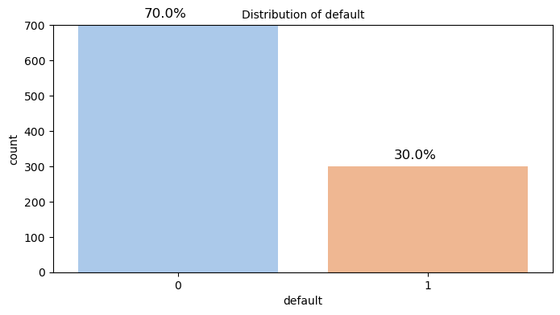

```python
# plot distribution of default to check if there's class imbalance or not
plt.figure(figsize=(8, 4))
plt.title("Distribution of default", fontsize=10)
plot = sns.countplot(x='default', data=credit_df_processed, palette='pastel')
plt.ylim(0, credit_df_processed['default'].value_counts().max() + 1)

def target(plot):
    total = len(credit_df_processed['default'])
    for p in plot.patches:
        percentage = '{:.1f}%'.format(100 * p.get_height() / total)
        x = p.get_x() + p.get_width() / 2 - 0.05
        y = p.get_y() + p.get_height()
        plot.annotate(percentage, (x, y), size=12, ha='center', va='center', xytext=(0, 10), textcoords='offset points')

target(plot)
plt.show()
```

#### Insights from boxplots (numerical features vs. default)

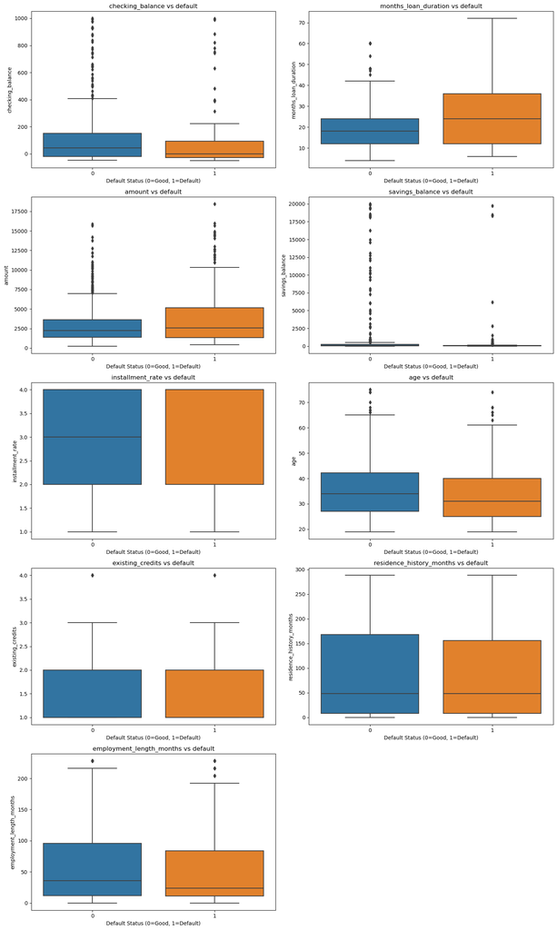

```python
def plot_numeric_vs_default(df, numeric_cols=None, target_col='default'):
    """
    Plot distribution of numeric variables against the default status.

    """
    if numeric_cols is None:
        numeric_cols = df.select_dtypes(include=['int64', 'float64']).columns.tolist()
        # Remove target column if it's in the list
        numeric_cols = [col for col in numeric_cols if col != target_col]

    n_cols = 2
    n_rows = int(np.ceil(len(numeric_cols) / n_cols))

    plt.figure(figsize=(15, 5 * n_rows))

    for i, col in enumerate(numeric_cols, 1):
        plt.subplot(n_rows, n_cols, i)

        # Create boxplots grouped by default status
        sns.boxplot(x=target_col, y=col, data=df)
        plt.title(f'{col} vs {target_col}')
        plt.xlabel('Default Status (0=Good, 1=Default)')
        plt.ylabel(col)

    plt.tight_layout()
    plt.show()

numeric_cols = ['checking_balance', 'months_loan_duration', 'amount', 'savings_balance','installment_rate',
               'age', 'existing_credits', 'residence_history_months', 'employment_length_months']
plot_numeric_vs_default(credit_df_processed, numeric_cols, target_col='default')
```

#### Insights from barplots (categorical columns vs. default)

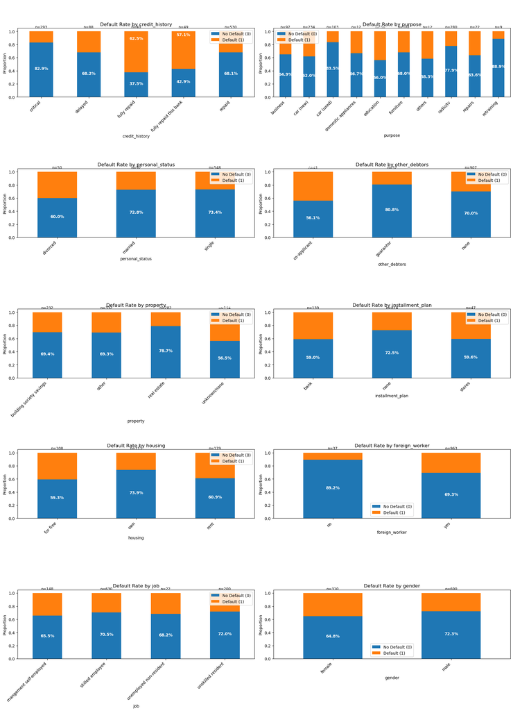

```python
def plot_categorical_vs_default(df, cat_cols=None, target_col='default'):
    """
    Plot distribution of categorical variables against the default status.

    """
    if cat_cols is None:
        cat_cols = df.select_dtypes(include=['object']).columns.tolist()
        cat_cols = [col for col in cat_cols if col != target_col]

    n_cols = 2
    n_rows = int(np.ceil(len(cat_cols) / n_cols))

    plt.figure(figsize=(18, 5 * n_rows))

    for i, col in enumerate(cat_cols, 1):
        plt.subplot(n_rows, n_cols, i)

        # Calculate default rates by category
        cross_tab = pd.crosstab(df[col], df[target_col], normalize='index')
        counts_by_cat = df[col].value_counts()
        cross_tab.plot(kind='bar', stacked=True, ax=plt.gca())
        for idx, count in enumerate(counts_by_cat.reindex(cross_tab.index)):
            plt.text(idx, 1.05, f'n={count}', ha='center', fontsize=9)

        plt.title(f'Default Rate by {col}')
        plt.xlabel(col)
        plt.ylabel('Proportion')
        plt.legend(['No Default (0)', 'Default (1)'])
        plt.xticks(rotation=45, ha='right')

        for idx, rate in enumerate(cross_tab[1]):
            non_default_rate = 1 - rate
            plt.text(idx, 0.5 + non_default_rate, f'{rate:.1%}', ha='center', fontsize=10,
                     color='white', fontweight='bold')
            plt.text(idx, non_default_rate/2, f'{non_default_rate:.1%}', ha='center', fontsize=10,
                     color='white', fontweight='bold')

    plt.tight_layout()
    plt.show()

cat_cols = ['credit_history', 'purpose', 'personal_status',
           'other_debtors', 'property', 'installment_plan', 'housing',
           'foreign_worker', 'job', 'gender']
plot_categorical_vs_default(credit_df_processed, cat_cols, target_col='default')
```

#### Fill in missing values

- Use median for numerical features with missing values
- Use mode (most frequent value) for categorical features with missing values

```python
def fill_missing_values(df):
    """
    Fill missing values in the DataFrame.
    """
    # Fill missing values in 'personal_status' with the mode
    mode_personal_status = df['personal_status'].mode()[0]
    df['personal_status'].fillna(mode_personal_status, inplace=True)

    # Fill missing values in numerical columns with the median
    numerical_cols = ['checking_balance', 'savings_balance', 'residence_history_months', 'employment_length_months']
    for col in numerical_cols:
        median_value = df[col].median()
        df[col].fillna(median_value, inplace=True)

    return df

credit_df_filled = fill_missing_values(credit_df_processed)
df_snapshot(credit_df_filled)
# check if missing values were filled correctly
null_checker(credit_df_filled)
```

|  | checking_balance | months_loan_duration | credit_history | purpose | amount | savings_balance | installment_rate | personal_status | other_debtors | property | age | installment_plan | housing | existing_credits | default | dependents | telephone | foreign_worker | job | gender | residence_history_months | employment_length_months |
| --- | --- | --- | --- | --- | --- | --- | --- | --- | --- | --- | --- | --- | --- | --- | --- | --- | --- | --- | --- | --- | --- | --- |
| 0 | -43.0 | 6 | critical | radio/tv | 1169 | 64.0 | 4 | single | none | real estate | 67 | none | own | 2 | 0 | 1 | 2.349340e+09 | yes | skilled employee | male | 72.0 | 156.0 |
| 1 | 75.0 | 48 | repaid | radio/tv | 5951 | 89.0 | 2 | single | none | real estate | 22 | none | own | 1 | 1 | 1 | NaN | yes | skilled employee | female | 5.0 | 24.0 |
| 2 | 24.0 | 12 | critical | education | 2096 | 24.0 | 2 | single | none | real estate | 49 | none | own | 1 | 0 | 2 | NaN | yes | unskilled resident | male | 48.0 | 60.0 |
| 3 | -32.0 | 42 | repaid | furniture | 7882 | 9.0 | 2 | single | guarantor | building society savings | 45 | none | for free | 1 | 0 | 2 | NaN | yes | skilled employee | male | 156.0 | 60.0 |
| 4 | -23.0 | 24 | delayed | car (new) | 4870 | 43.0 | 3 | single | none | unknown/none | 53 | none | for free | 2 | 1 | 2 | NaN | yes | skilled employee | male | 156.0 | 36.0 |

```
                          Null Count  Null Percentage  Row Count
telephone                        596             59.6       1000
checking_balance                   0              0.0       1000
months_loan_duration               0              0.0       1000
residence_history_months           0              0.0       1000
gender                             0              0.0       1000
job                                0              0.0       1000
foreign_worker                     0              0.0       1000
dependents                         0              0.0       1000
default                            0              0.0       1000
existing_credits                   0              0.0       1000
housing                            0              0.0       1000
installment_plan                   0              0.0       1000
age                                0              0.0       1000
property                           0              0.0       1000
other_debtors                      0              0.0       1000
personal_status                    0              0.0       1000
installment_rate                   0              0.0       1000
savings_balance                    0              0.0       1000
amount                             0              0.0       1000
purpose                            0              0.0       1000
credit_history                     0              0.0       1000
employment_length_months           0              0.0       1000
```

##### Convert categorical columns to numeric

- Use One-hot encoding to convert categorical columns such as foreign_worker, job, gender to numerical columns.
- This is important because machine learning models understand number not text

```python
def one_hot_encode_categorical_columns(df, categorical_columns):
    """
    Perform one-hot encoding on specified categorical columns in the DataFrame.

    """
    # Perform one-hot encoding
    df_encoded = pd.get_dummies(df, columns=categorical_columns, drop_first=True)

    return df_encoded

categorical_columns = ['credit_history', 'purpose', 'personal_status', 'other_debtors',
                       'property', 'installment_plan', 'housing', 'foreign_worker', 'job', 'gender']

credit_df_encoded = one_hot_encode_categorical_columns(credit_df_filled, categorical_columns)
df_snapshot(credit_df_encoded)
```

|  | checking_balance | months_loan_duration | amount | savings_balance | installment_rate | age | existing_credits | default | dependents | telephone | residence_history_months | employment_length_months | credit_history_delayed | credit_history_fully repaid | credit_history_fully repaid this bank | credit_history_repaid | purpose_car (new) | purpose_car (used) | purpose_domestic appliances | purpose_education | purpose_furniture | purpose_others | purpose_radio/tv | purpose_repairs | purpose_retraining | personal_status_married | personal_status_single | other_debtors_guarantor | other_debtors_none | … |
| --- | --- | --- | --- | --- | --- | --- | --- | --- | --- | --- | --- | --- | --- | --- | --- | --- | --- | --- | --- | --- | --- | --- | --- | --- | --- | --- | --- | --- | --- | --- |
| 0 | -43.0 | 6 | 1169 | 64.0 | 4 | 67 | 2 | 0 | 1 | 2.349340e+09 | 72.0 | 156.0 | 0 | 0 | 0 | 0 | 0 | 0 | 0 | 0 | 0 | 0 | 1 | 0 | 0 | 0 | 1 | 0 | 1 | … |
| 1 | 75.0 | 48 | 5951 | 89.0 | 2 | 22 | 1 | 1 | 1 | NaN | 5.0 | 24.0 | 0 | 0 | 0 | 1 | 0 | 0 | 0 | 0 | 0 | 0 | 1 | 0 | 0 | 0 | 1 | 0 | 1 | … |
| 2 | 24.0 | 12 | 2096 | 24.0 | 2 | 49 | 1 | 0 | 2 | NaN | 48.0 | 60.0 | 0 | 0 | 0 | 0 | 0 | 0 | 0 | 1 | 0 | 0 | 0 | 0 | 0 | 0 | 1 | 0 | 1 | … |
| 3 | -32.0 | 42 | 7882 | 9.0 | 2 | 45 | 1 | 0 | 2 | NaN | 156.0 | 60.0 | 0 | 0 | 0 | 1 | 0 | 0 | 0 | 0 | 1 | 0 | 0 | 0 | 0 | 0 | 1 | 1 | 0 | … |
| 4 | -23.0 | 24 | 4870 | 43.0 | 3 | 53 | 2 | 1 | 2 | NaN | 156.0 | 36.0 | 1 | 0 | 0 | 0 | 1 | 0 | 0 | 0 | 0 | 0 | 0 | 0 | 0 | 0 | 1 | 0 | 1 | … |

```python
def set_features_and_target(df):
    '''
    Returns two data frames with features and target variables.
            Parameters:
                    df (str): Pandas dataframe
    '''
    X = df.drop(['default','telephone'], axis=1)
    y = df['default']

    return X,y

X,y = set_features_and_target(credit_df_encoded)
print(X.shape, y.shape)
df_snapshot(X)
```

```
(1000, 39) (1000,)
```

|  | checking_balance | months_loan_duration | amount | savings_balance | installment_rate | age | existing_credits | dependents | residence_history_months | employment_length_months | credit_history_delayed | credit_history_fully repaid | credit_history_fully repaid this bank | credit_history_repaid | purpose_car (new) | purpose_car (used) | purpose_domestic appliances | purpose_education | purpose_furniture | purpose_others | purpose_radio/tv | purpose_repairs | purpose_retraining | personal_status_married | personal_status_single | other_debtors_guarantor | other_debtors_none | property_other | property_real estate | … |
| --- | --- | --- | --- | --- | --- | --- | --- | --- | --- | --- | --- | --- | --- | --- | --- | --- | --- | --- | --- | --- | --- | --- | --- | --- | --- | --- | --- | --- | --- | --- |
| 0 | -43.0 | 6 | 1169 | 64.0 | 4 | 67 | 2 | 1 | 72.0 | 156.0 | 0 | 0 | 0 | 0 | 0 | 0 | 0 | 0 | 0 | 0 | 1 | 0 | 0 | 0 | 1 | 0 | 1 | 0 | 1 | … |
| 1 | 75.0 | 48 | 5951 | 89.0 | 2 | 22 | 1 | 1 | 5.0 | 24.0 | 0 | 0 | 0 | 1 | 0 | 0 | 0 | 0 | 0 | 0 | 1 | 0 | 0 | 0 | 1 | 0 | 1 | 0 | 1 | … |
| 2 | 24.0 | 12 | 2096 | 24.0 | 2 | 49 | 1 | 2 | 48.0 | 60.0 | 0 | 0 | 0 | 0 | 0 | 0 | 0 | 1 | 0 | 0 | 0 | 0 | 0 | 0 | 1 | 0 | 1 | 0 | 1 | … |
| 3 | -32.0 | 42 | 7882 | 9.0 | 2 | 45 | 1 | 2 | 156.0 | 60.0 | 0 | 0 | 0 | 1 | 0 | 0 | 0 | 0 | 1 | 0 | 0 | 0 | 0 | 0 | 1 | 1 | 0 | 0 | 0 | … |
| 4 | -23.0 | 24 | 4870 | 43.0 | 3 | 53 | 2 | 2 | 156.0 | 36.0 | 1 | 0 | 0 | 0 | 1 | 0 | 0 | 0 | 0 | 0 | 0 | 0 | 0 | 0 | 1 | 0 | 1 | 0 | 0 | … |

```python
def train_test_split_df(X,y):
    '''
    Creates train and test split.

    '''

    X_train, X_test, y_train, y_test = train_test_split(X, y, test_size=0.3, random_state=42,  stratify=y)

    return X_train, X_test, y_train, y_test

X_train, X_test, y_train, y_test = train_test_split_df(X,y)
print(X_train.shape,y_train.shape)
print(X_test.shape,y_test.shape)
```

```
(700, 39) (700,)
(300, 39) (300,)
```

```python
def model_application(X_train, y_train, optimiser):
    '''
    Model application. If optimiser is True, a grid search is applied to optimise the model.
    If optimiser is False, the baseline model is used.
    '''
    if optimiser:
        # Define parameter grid for XGBoost
        params = {
            'max_depth': [3, 6, 9],
            'learning_rate': [0.01, 0.1, 0.2],
            'subsample': [0.7, 0.9],
            'colsample_bytree': [0.7, 0.9],
            'scale_pos_weight': [2, 3]  # Controls class imbalance (approx ratio of negative:positive)
        }

        cv = StratifiedShuffleSplit(n_splits=5, test_size=0.3, random_state=15)

        # Use Recall for scoring
        model = XGBClassifier(random_state=42, eval_metric='logloss')
        grid = GridSearchCV(model, param_grid=params, scoring='recall', n_jobs=-1, cv=cv, verbose=1)
        grid.fit(X_train, y_train)

        print('Best Score:', grid.best_score_)
        print('Best Params:', grid.best_params_)
        print('Best Estimator:', grid.best_estimator_)

        model = grid.best_estimator_
    else:
        # Baseline XGBoost
        model = XGBClassifier(
            n_estimators=200,
            max_depth=6,
            learning_rate=0.1,
            subsample=0.8,
            colsample_bytree=0.8,
            scale_pos_weight=3,
            random_state=42,
            eval_metric='logloss'
        )
        model.fit(X_train, y_train)

    return model

optimiser = True
xgb_clf = model_application(X_train, y_train, optimiser)
```

```
Fitting 5 folds for each of 72 candidates, totalling 360 fits
Best Score: 0.8222222222222222
Best Params: {'colsample_bytree': 0.7, 'learning_rate': 0.01, 'max_depth': 3, 'scale_pos_weight': 3, 'subsample': 0.9}
Best Estimator: XGBClassifier(base_score=None, booster=None, callbacks=None,
              colsample_bylevel=None, colsample_bynode=None,
              colsample_bytree=0.7, device=None, early_stopping_rounds=None,
              enable_categorical=False, eval_metric='logloss',
              feature_types=None, gamma=None, grow_policy=None,
              importance_type=None, interaction_constraints=None,
              learning_rate=0.01, max_bin=None, max_cat_threshold=None,
              max_cat_to_onehot=None, max_delta_step=None, max_depth=3,
              max_leaves=None, min_child_weight=None, missing=nan,
              monotone_constraints=None, multi_strategy=None, n_estimators=None,
              n_jobs=None, num_parallel_tree=None, random_state=42, ...)
```

```python
def model_predict(X_test):
    '''
    Create y_pred , model prediction based on test set features.
    '''
    y_pred = xgb_clf.predict(X_test)

    return y_pred

y_pred = model_predict(X_test)
print('Training Accuracy Score(%):',xgb_clf.score(X_train,y_train)*100)
print('Test Accuracy Score(%):',xgb_clf.score(X_test,y_test)*100)
```

```
Training Accuracy Score(%): 66.71428571428571
Test Accuracy Score(%): 61.0
```

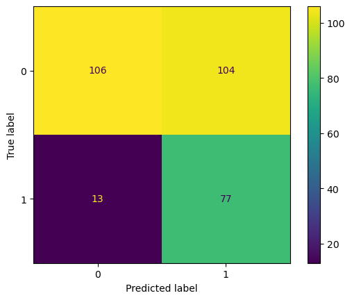

```
array([[106, 104],
       [ 13,  77]])
```

```python
def generate_confusion_matrix(y_test, y_pred):
    '''
    Generates confusion matrix.
    '''

    cm = confusion_matrix(y_test, y_pred, labels=rf_clf.classes_)
    disp = ConfusionMatrixDisplay(confusion_matrix=cm, display_labels=rf_clf.classes_)
    disp.plot()
    plt.grid(False)
    plt.show()

    return cm

generate_confusion_matrix(y_test, y_pred)
```

```python
def generate_perfomance_metrics(y_test,y_pred):
    '''
    Generates perfomance metrics precision, recall, f1 score, accuracy
    '''
    rf_model_score = accuracy_score(y_test, y_pred)
    print('Model Accuracy:', rf_model_score)
    return print('Classification Report:\n', classification_report(y_test, y_pred))

generate_perfomance_metrics(y_test,y_pred)
```

```
Model Accuracy: 0.61
Classification Report:
               precision    recall  f1-score   support

           0       0.89      0.50      0.64       210
           1       0.43      0.86      0.57        90

    accuracy                           0.61       300
   macro avg       0.66      0.68      0.61       300
weighted avg       0.75      0.61      0.62       300
```

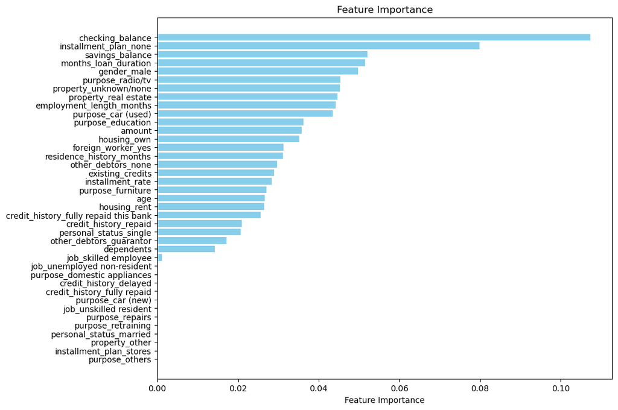

```python
def plot_feature_importance(rf_clf, feature_names):
    """
    Plot feature importance from a Random Forest classifier.
    """
    # Get feature importances
    importances = xgb_clf.feature_importances_

    # Create a DataFrame for feature importances
    feature_importance_df = pd.DataFrame({'Feature': feature_names, 'Importance': importances})
    feature_importance_df = feature_importance_df.sort_values(by='Importance', ascending=True)

    plt.figure(figsize=(10, 8))
    plt.barh(feature_importance_df['Feature'], feature_importance_df['Importance'], color='skyblue')
    plt.xlabel('Feature Importance')
    plt.title('Feature Importance')
    plt.show()

feature_names = X_train.columns.tolist()
plot_feature_importance(xgb_clf, feature_names)
```

### Model Insights

#### Model Performance:

Precision:

- For class 0 (No Default), the precision is 0.89, meaning that 89% of the instances predicted as No Default are actually No Default.
- For class 1 (Default), the precision is 0.43, meaning that 43% of the instances predicted as Default are actually Default.

Recall:

- For class 0, the recall is 0.50, meaning that 50% of the actual No Default instances are correctly identified.
- For class 1, the recall is 0.86, meaning that 86% of the actual Default instances are correctly identified.

F1-Score:

Choice of Scoring Function:

- Recall: The choice of recall as the scoring function is justified by the business context of predicting credit defaults. In this scenario, it is crucial to identify as many actual Default instances as possible to mitigate potential financial losses. A high recall for the Default class (0.86) indicates that the model is effective in capturing most of the actual Default instances, even though it may result in a some false positives.

#### Business Impact:

- The model's high recall for class 1 (Default) indicates that it is effective in identifying most of the actual Default instances. This can be valuable for in identifying high-risk loan applicants and reducing the likelihood of defaults.
- The model can be used to implement risk management strategies, such as offering different loan terms or interest rates based on the predicted risk of default.
- The high recall for Default instances can help in mitigating potential losses by identifying most of the high-risk applicants.
- The model can help in segmenting customers based on their risk profiles. This can enable targeted marketing and personalized loan products for different customer segments.
- Automating the loan default prediction process can improve operational efficiency by reducing the time and resources required for manual credit assessments. This can lead to faster loan approval processes and improved customer satisfaction.

#### Feature Importance:

- The analysis of feature importance from the model, combined with insights from exploratory data analysis (EDA), reveals several key factors that significantly influence loan default predictions. These insights can guide in making informed decisions and implementing effective risk management strategies.

Financial Stability Indicators:

- Features such as checking balance, savings balance, and property ownership are strong predictors of loan default. Higher balances and property ownership are associated with lower default risk, reflecting financial stability. This aligns with EDA insights, where lower balances and unknown property status were linked to higher default rates.

Loan Characteristics:

- The model identified Loan duration and loan amount as crucial factors, with longer durations and higher loan amounts increasing the risk of default. EDA insights also highlighted that larger loan amounts and longer durations are risk factors for default.

Employment and Residence Stability:

- Longer employment histories and residence durations are indicative of lower default risk. EDA insights also showed that shorter employment lengths and residence histories are more common among defaulters.

Demographic Factors:

- Gender and age play a notable role in default risk, with different demographic groups exhibiting varying default rates. EDA insights also noted demographic-specific default rates, such as higher rates among divorced individuals and foreign workers.

Loan Purpose:

- The purpose of the loan impact default risk, with some purposes and plans being riskier than others. EDA insights revealed that loans for business and education have higher default rates, while ratio/tv loan purpose had lowe default rates as aksi detected by the model.

Housing Status:

- Housing status, such as owning or renting, influences default risk, with ownership indicating lower risk. EDA insights also showed that individuals who own their housing have lower default rates, while those who live for free have higher rates.

### Improvement Suggestions:

- With more time I'd address data imbalance with various techniques such as SMOTE (Synthetic Minority Over-sampling Technique) to generate synthetic samples for the minority class or adjust class weights in the model to give more importance to the minority class.
- Explore additional feature engineering to create new features that might capture more information relevant to predicting defaults.
- Experiment with other models that might handle imbalanced data better and compare performance.
- Consider the business context and the cost of misclassification. For example, the cost of denying a loan to a non-risky applicant (false positive) versus approving a loan to a risky applicant (false negative) then tailor the model's decision threshold based on the business impact.